# Contention and the internet

# The internet and social movements

## Gezi Park Protests

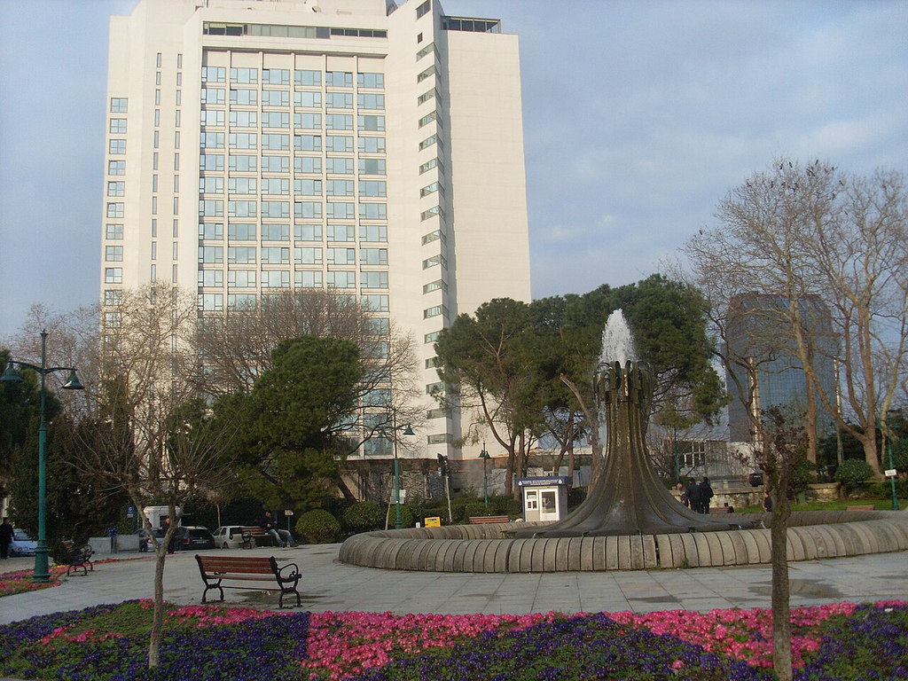

Gezi Park

## Gezi Park Protests

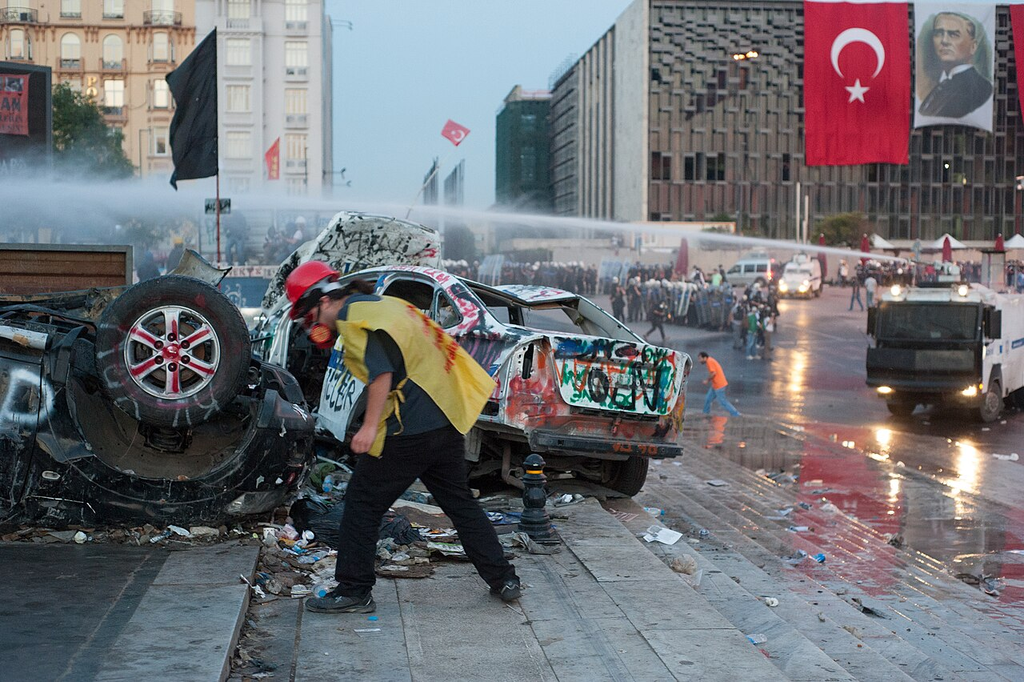

## Gezi Park Protests

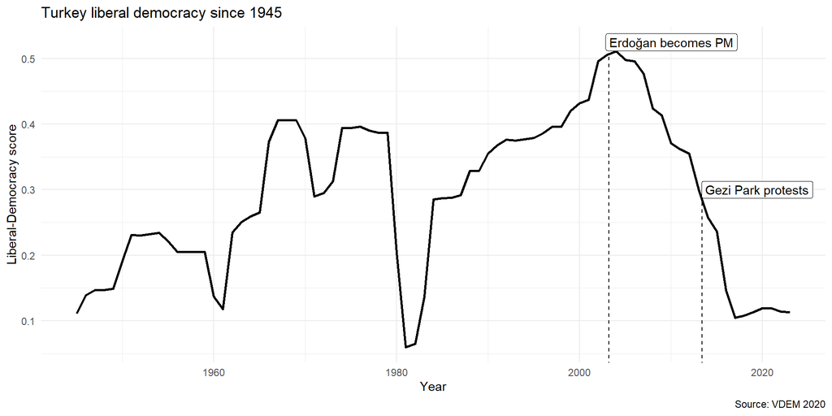

## Gezi Park and social media

- Not the first protest to use twitter, but notable for the sheer volume of social media activity related to the protests and their perceived importance for activists and opponents:

> “Now we have a menace that is called Twitter… To me, social media is the worst menace to society” - Recep Tayyip Erdoğan

## Gezi Park and social media

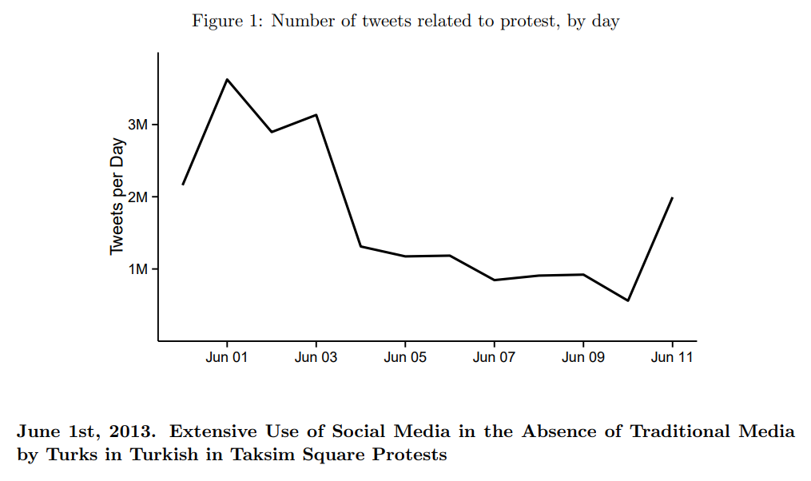

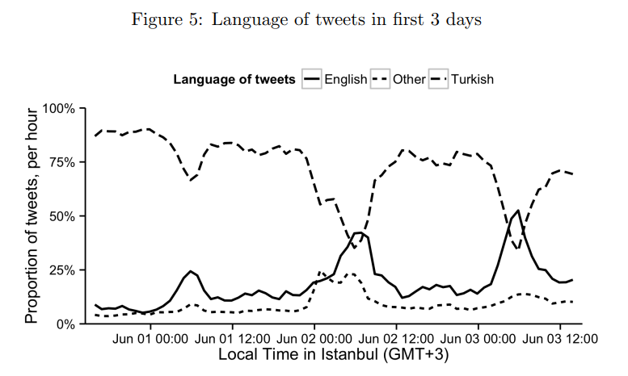

(“A Breakout Role for Twitter? The Role of Social Media in the Turkish Protests” 2013)

## The internet and contentious politics

- There’s some consensus that the internet “matters” for contentious actors
- There’s not a consensus on whether it is a net positive or a net negative and how fundamentally it changes the calculus for contentious behavior.

[figure not shown]

## The internet as a tool

- Information sharing (even under repression)

[figure not shown]

Inspire Magazine: online publication released by Al-Qaeda

## The internet as a tool

- Information sharing (even under repression)
- Mobilization, framing and identity building (without the need for mainstream press coverage or direct social interaction)

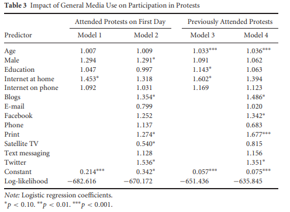

(Tufekci and Wilson 2012)

## The internet as a tool

- A study of Gezi park social media activity found connections to the “periphery” were critical for spreading the messages and experiences of participants. (Barberá et al. 2015)

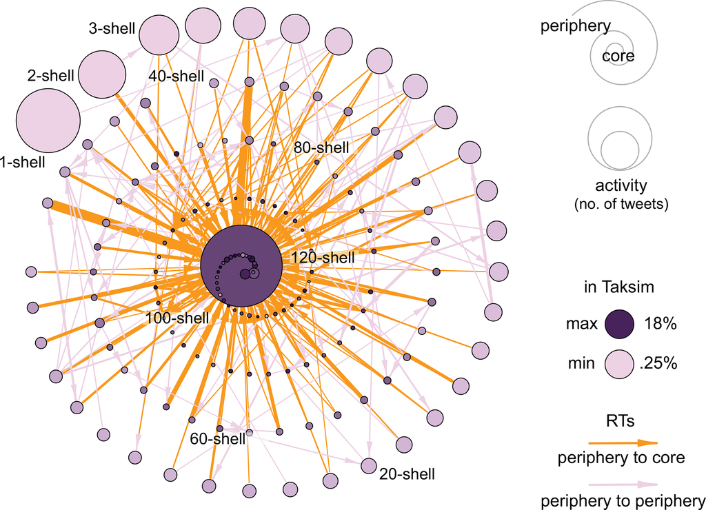

## The internet as a venue

- The internet itself is increasingly a *site* of contention:
  - Online boycotts
  - Coordinated harassment or pressure campaigns
  - Politically motivated hacks

[figure not shown]

Wikipedia’s SOPA/PIPA blackout message

## Reasons for skepticism

### High risk activism

- Classic Studies of “high-risk” activism found that strong social ties were key: committed activists are part of a community.
- ICT facilitated movements are wide-but-shallow.

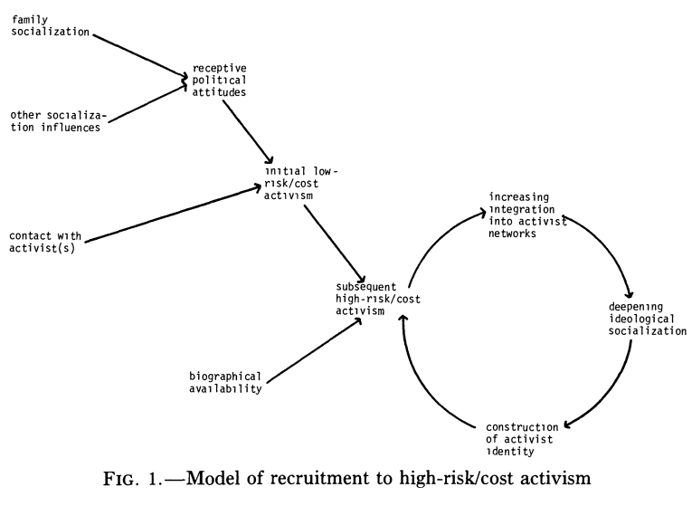

### Slacktivism

- **Catharsis** is the process of getting relief from an emotion by expressing it.
- **Slacktivism** refers to low-cost, low risk activities that express support or raise awareness of an issue.
- Taken together: opportunities for slacktivism might sap energy that would otherwise lead people to more impactful forms of participation

## Online repression

The same tools that can facilitate contention can also facilitate repression and propaganda.

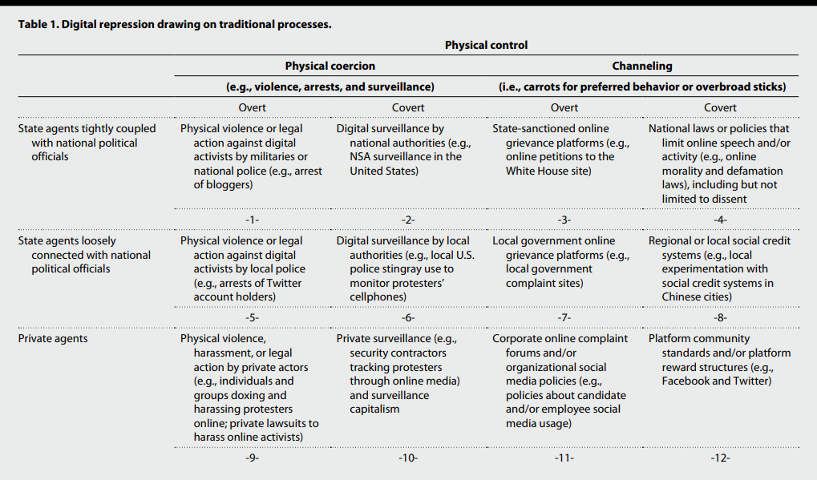

(Earl, Maher, and Pan 2022)

## Online repression

[figure not shown]

## Online repression

- Social media is centralized and less anonymous than might be assumed, so they can make systematic low-level repression easier.
- The same resource advantages that favor corporate and state actors offline are mirrored in online spaces.

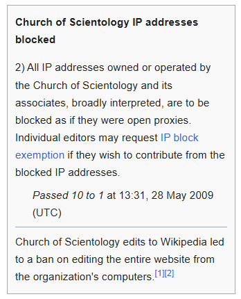

## Online repression

- States have gotten much better at repressing online contention over time.
- (King, Pan, and Roberts 2013) found evidence of industrial-scale censorship of Chinese social media posts. Primarily targeted at efforts to mobilize people for offline activity.

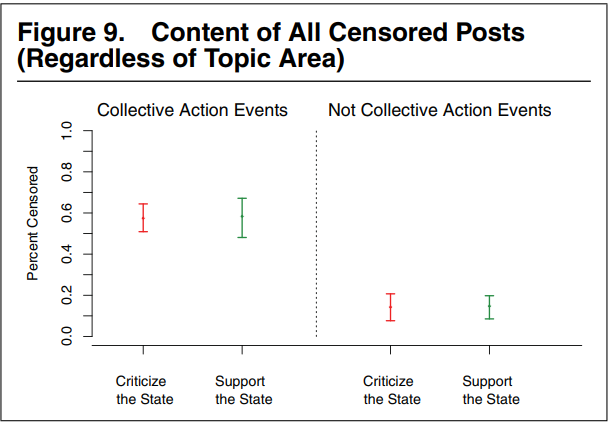

## Online repression

> “We estimate that the government fabricates and posts about 448 million social media comments a year.”

(King, Pan, and Roberts 2017)

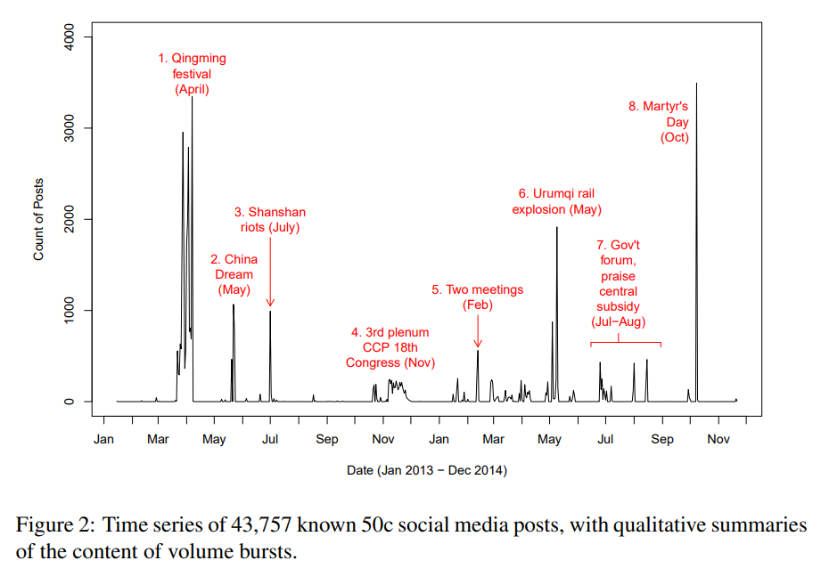

## Online repression

Examples of “cheerleading”

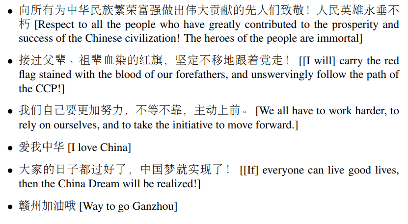

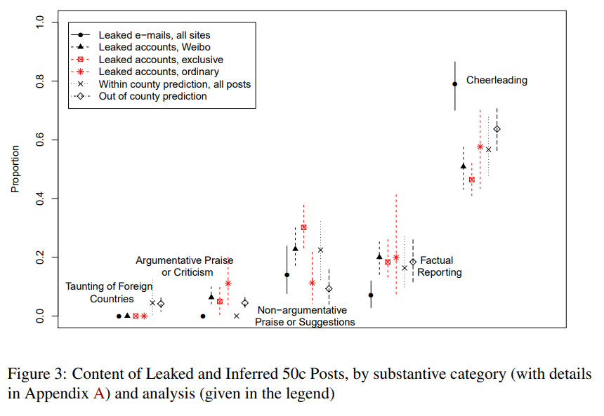

(King, Pan, and Roberts 2017)

## References

[figure not shown]

“A Breakout Role for Twitter? The Role of Social Media in the Turkish Protests.” 2013. Social Media; Political Participation Lab New York University.

Barberá, Pablo, Ning Wang, Richard Bonneau, John T Jost, Jonathan Nagler, Joshua Tucker, and Sandra González-Bailón. 2015. “The Critical Periphery in the Growth of Social Protests.” *PloS One* 10 (11): e0143611.

Earl, Jennifer, Thomas V Maher, and Jennifer Pan. 2022. “The Digital Repression of Social Movements, Protest, and Activism: A Synthetic Review.” *Science Advances* 8 (10): eabl8198.

King, Gary, Jennifer Pan, and Margaret E Roberts. 2013. “How Censorship in China Allows Government Criticism but Silences Collective Expression.” *American Political Science Review* 107 (2): 326–43.

———. 2017. “How the Chinese Government Fabricates Social Media Posts for Strategic Distraction, Not Engaged Argument.” *American Political Science Review* 111 (3): 484–501.

Tufekci, Zeynep, and Christopher Wilson. 2012. “Social Media and the Decision to Participate in Political Protest: Observations from Tahrir Square.” *Journal of Communication* 62 (2): 363–79.